# Communicate Data Findings

### Factors that impact the optimum loan for an applicant.

## Data Source

- Name: prosperLoanData.csv
- Definition: Loan Data from Prosper
- Source: https://s3.amazonaws.com/udacity-hosted-downloads/ud651/prosperLoanData.csv
- Detail: This data set contains 113,937 loans with 81 variables on each loan, including loan amount, borrower rate (or interest rate),current loan status, borrower income, and many others

## Summary of Exploratory Data

### 1. Univariate Exploration

- Original Loan amount is right skewed. Most of the loan amount are in range of 0-5000.
- Most of the Loan status is Current. Apart from it we can see alot of completed loan case.
- 54.4% of the borrower's are homeowner.
- Most of the borrowers are employed amd full-time worker.
- There are very few people(4.7%) with income less than 24,999.
- Loans with "AA" category are with lesser count
- There are alot of borrower's with prosperScore less than 6.0. Based on this we can say loan was even provided to people with high risk score.
- Most of the borrower's didn't specify there occupation that was given in form, they wrote Other.
- Apart from that "Professional", "Executive", "Computer Programmer", "Teacher", and "Analyst" are the top 5 most common occupations of the borrower's.
- There are 0.1% borrowers without verfied income.
- 50% of borrowerARP is in range of 0.161570 - 0.287800
- The borrowers rate follow an approximately unimodal distribution, with the peak around 0.16
- The monthly income the borrower stated at the time the listing was created. Monthly Income will definitely be right skewed since very few people will be having a higher salary.

### 2. Bivariate Exploration

- Negative correlation between BorrowerRate and Prosper Score, means lower the prosper rate, higher will be the borrower rate
- Higher loan amount is associated with high monthly payment, as they are have strong positive correlation.
- Loan original amount and monthly loan payment is highly positive correlated,
- Borrowers interest rate and proper score are highly negatively correlated,
- Borrower interest rate and Loan original amount are negatively correlated.
- Full-time employs have generally high prosper rating than others.
- Self-employed people have low prosper rating
- Executives, Pharmacist, Doctors and Judge have large loan amount in comparision to other occupants
- People with high Income range took high loan amount.
- Prosper Rating B and C have most number of people who are employed.
- Borrowers with salary range are between 50,000− 74,999 are mostly in prosper rating of A, B, C or D.

## Explanatory Data Visualization

### Question : Does loan amount impact the borrower interest rate?

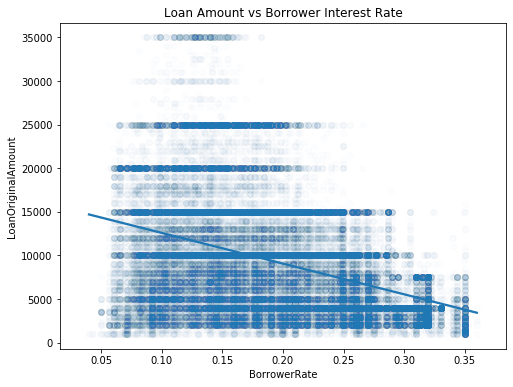

#### Conclusion:

- Borrower interest rate and Loan original amount have moderate negative correlation. Thus we expect that for higher loan amount, the borrower interest rate will be lesser.

### Question : What is the impact of prosper score on borrower interest rate?

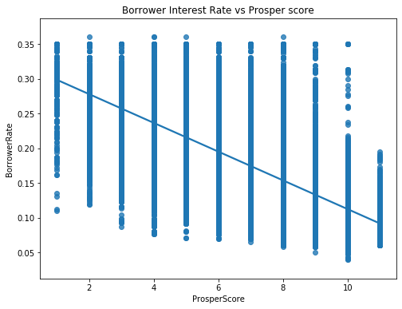

#### Conclusion:

- Borrowers interest rate and proper score are negatively correlated. With lower prosper score, the borrower interest rate tends to increase. Therefore, more the prosper score will be, lesser will be the interest rate.

### Question: Can we conclude anything regarding the relationship between ProsperScore and Employment Status?? Does certain Employment status lead to better chance of getting optimum loan ?

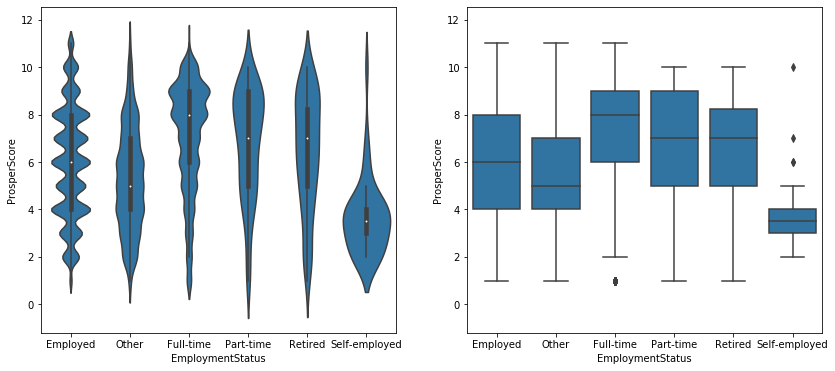

#### Conslusion:

- Full-time employs have generally high prosper rating than others, and have better chance of getting loan easily with lesser borrower interest rate.
- Self-employed people have low prosper rating, thus it's hard for them to get high loan amount with lesser borrower interest rate.

### Question: Can we find any conclusion using prosper rating, loan amount and income range?

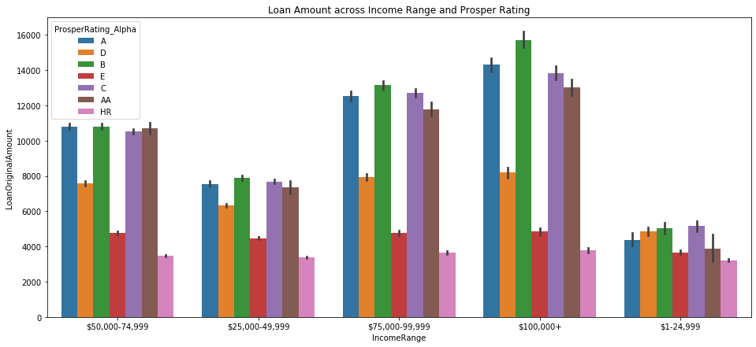

#### Conclusion:

- Large amount of loan is easily provideed to those will high income range and they have generally better prosper rating than other, thus their borrower interest rate would alse be lesser than others.

### Question : Does being a Homeownner any impact on Borrower Rate and Prosper Rating ?

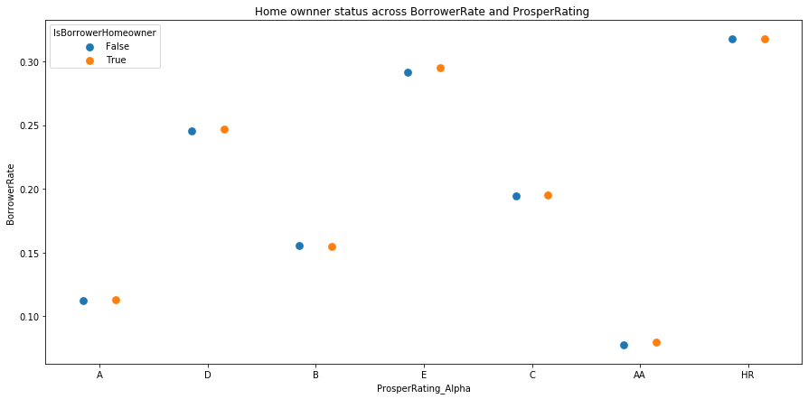